# RとPythonは仲良し

やわらかクジラ

2024/08/31

# 1 本資料の説明

- 第100回 Tokyo.Rでの発表に向けて自分のために作ったRとPython連携周りのメモ
- 発表資料は[こちら](https://github.com/izunyan/practice_py_r/tree/main/pdf)
- このhtmlは常に更新され続けます

# 2 🐍インストールから環境設定周り

## 2.1 Python使用環境について

- 詳しくは上記発表資料のスライド「Pythonを始める方法（用途：基本的なデータ分析）」参照
- Python直インストールで必要なライブラリは都度入れていくスタイルで進める

[figure not shown]

## 2.2 WindowsでのPythonインストール

- 公式サイトでダウンロード
  - https://www.python.org/downloads/
- `Add Python 3.x to PATH`にチェックを入れる
  - 参照：https://www.python.jp/install/windows/install.html
  - ただし，複数バージョンのpythonを使う必要があるなどの場合は，チェックを入れずに，やったほうがよいこともある
  - VS Codeで違うバージョンのpython使いたい時は，`F1 > Python:select interpreter`で対応

## 2.3 パッケージの管理（pip関連）

以下はWindowsでのやり方のみ

- 以下，RStudioのTerminalから実行
  - ただし仮想環境あるとできないぽい？
  - Windowsでは，コマンドプロンプトからも実行できる
  - `Windowsキー＋R`，または，タスクバーにある「ここに入力して検索」に`cmd`と入れて検索
- 入っているPythonの一覧確認
  - `py --list`
- pipが適用されるPythonのバージョン確認
  - `python -V`
- 省略しても実行可能だが，`python -m`を最初につけることが推奨されている
- インストール済みパッケージの確認
  - `python -m pip list`
- パッケージインストール
  - `python -m pip install ここにパッケージ名`
- アップデートが必要なパッケージ一覧
  - `python -m pip list -o`
- パッケージのアップデート
  - `python -m pip install -U ここにパッケージ名`
- パッケージを一括でアップデート
  - `pip-review --auto`
- pip自体のアップデート
  - `python -m pip install --upgrade pip`

### 2.3.1 【参考】Terminal OR コマンドプロンプトの操作

- 現在のディレクトリ表示
  - `pwd`
- ディレクトリ内のファイル一覧表示
  - `dir`
- 1つ上の階層に移動
  - `cd ..`
- ルートに移動
  - `cd \`
- ディレクトリに移動しカレントに
  - `cd ここにパス,カレントディレクトリ内ならフォルダ名`
- フォルダ作成
  - `mkdir フォルダ名`
- 構造図式化
  - `tree`

## 2.4 Pythonコードの実行

- RとPythonで実行結果をやり取りするためにRマークダウンを使用

[figure not shown]

- Minicondaのインストールを求められても’n’を入力

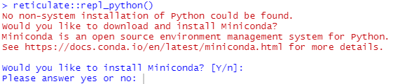

## 2.5 VSCodeのメモ

- [web版](https://code.visualstudio.com/docs/editor/vscode-web)もある

### 2.5.1 設定

- `Preferences > Settings`
- `Ctrl-Shift-P` or `F1`

## 2.6 その他

### 2.6.1 ブラウザからjupyter labを使うこともできる

- 入ってなければインストール
  - `python -m install jupyterlab`
- terminalで次のコマンドを実行するとブラウザで開かれる
  - `jupyter lab`

### 2.6.2 仮想環境:venv(本記事では扱わないが参考のためメモ)

- 以下，コマンドプロンプトまたはRStudioのTerminalから実行
- 仮想環境作成
  - まずcdで仮想環境のフォルダを作りたいディレクトリに移動
  - 仮想環境フォルダ作成 `python -m venv .venv`
    - 名前は任意,ここではよく使われる`.venv`を使用
  - Pythonのバージョンを指定したい時の例`py -3.11 -m venv .venv`
- 仮想環境に入る `.venv\Scripts\activate`
- 仮想環境から出る `deactivate`
- Git管理から外すために`.gitignore`にフォルダ名を追記しておく

## 2.7 実行環境

### 2.7.1 R

```r
sinfo <-
sessioninfo::session_info()

sinfo$platform
```

```
##  setting  value
##  version  R version 4.4.1 (2024-06-14 ucrt)
##  os       Windows 10 x64 (build 19045)
##  system   x86_64, mingw32
##  ui       RTerm
##  language (EN)
##  collate  Japanese_Japan.utf8
##  ctype    Japanese_Japan.utf8
##  tz       Asia/Tokyo
##  date     2024-08-31
##  pandoc   3.1.1 @ C:/Program Files/RStudio/resources/app/bin/quarto/bin/tools/ (via rmarkdown)
```

### 2.7.2 RStudio version

```r
rsinfo <-
rstudioapi::versionInfo()

rsinfo$version
```

```
## [1] '2023.9.0.463'
```

### 2.7.3 Python

```r
reticulate::py_version()
```

[output not shown]

# 3 基本用語

## 3.1 R

### 3.1.1 ベクトル

```r
r_vec <- c(1, 2, 3)
r_vec
```

```
## [1] 1 2 3
```

### 3.1.2 名前付きベクトル

```r
r_nvec <- c(a = 1, b = 2, c = 3)
r_nvec
```

```
## a b c
## 1 2 3
```

### 3.1.3 リスト

```r
r_l <- list(1, 2, 3)
r_l
```

```
## [[1]]
## [1] 1
##
## [[2]]
## [1] 2
##
## [[3]]
## [1] 3
```

### 3.1.4 名前付きリスト

```r
r_nl <- list(a = 1, b = 2, c = 3)
r_nl
```

```
## $a
## [1] 1
##
## $b
## [1] 2
##
## $c
## [1] 3
```

## 3.2 python

- https://docs.python.org/ja/3/tutorial/datastructures.html#data-structures

### 3.2.1 リスト

```python
py_l = [1,2,3]
py_l
```

```
## [1, 2, 3]
```

```python
py_l2 = [1,'a',3]
py_l2
```

```
## [1, 'a', 3]
```

### 3.2.2 辞書型：dictionary

```python
py_d = {'x':1, 'y':2}
py_d
```

```
## {'x': 1, 'y': 2}
```

### 3.2.3 タプル：tuple

```python
py_t = (3,4,5)
py_t
```

```
## (3, 4, 5)
```

### 3.2.4 np.array 配列

```python
import numpy as np
py_ndarray = np.array([1,2,3])
py_ndarray
```

```
## array([1, 2, 3])
```

```python
py_ndarray2 = np.array([[1,2,3],[4,5,6]])
py_ndarray2
```

```
## array([[1, 2, 3],
##        [4, 5, 6]])
```

### 3.2.5 メソッド

- データに結びついた関数

https://www.python.jp/train/string/method.html

# 4 📙Rとpythonで相互の読み込み

## 4.1 RとPythonでデータフレームのやり取り

- 緑チャンクがpython

### 4.1.1 Rでデータフレーム読み込み

```r
library(reticulate)

df_r <- palmerpenguins::penguins
```

### 4.1.2 PythonでRのデータフレーム読み込みして列選択

- 注意！：整数型のNAが，Pythonでは-2147483648と読み込まれる
- 関係する議論
  - [What should NA be converted to in Python?](https://github.com/rstudio/reticulate/issues/197)
  - [Preserve NAs when casting R data.frames to pandas.](https://github.com/rstudio/reticulate/pull/1439)
- 以下，入っていなければterminalでパッケージをインストールしておく python -m pip install pandas polars seaborn pyarrow numpy openpyxl

```python
import pandas as pd

r.df_r.head()
```

```
##   species     island  bill_length_mm  ...  body_mass_g     sex  year
## 0  Adelie  Torgersen            39.1  ...         3750    male  2007
## 1  Adelie  Torgersen            39.5  ...         3800  female  2007
## 2  Adelie  Torgersen            40.3  ...         3250  female  2007
## 3  Adelie  Torgersen             NaN  ...  -2147483648     NaN  2007
## 4  Adelie  Torgersen            36.7  ...         3450  female  2007
##
## [5 rows x 8 columns]
```

```python
df_py = r.df_r[['species',  'bill_length_mm']]
```

- 解決策

```r
options(reticulate.pandas_use_nullable_dtypes = TRUE)
```

```python
r.df_r.head()
```

```
##   species     island  bill_length_mm  ...  body_mass_g     sex  year
## 0  Adelie  Torgersen            39.1  ...         3750    male  2007
## 1  Adelie  Torgersen            39.5  ...         3800  female  2007
## 2  Adelie  Torgersen            40.3  ...         3250  female  2007
## 3  Adelie  Torgersen            <NA>  ...         <NA>     NaN  2007
## 4  Adelie  Torgersen            36.7  ...         3450  female  2007
##
## [5 rows x 8 columns]
```

### 4.1.3 RからPythonで加工したデータフレーム読み込み

```r
head(py$df_py)
```

```
##   species bill_length_mm
## 1  Adelie           39.1
## 2  Adelie           39.5
## 3  Adelie           40.3
## 4  Adelie             NA
## 5  Adelie           36.7
## 6  Adelie           39.3
```

```r
rm(df_r) # df削除
```

## 4.2 ここまで作ったオブジェクトの整理

### 4.2.1 pythonのオブジェクト削除

```python
del df_py
```

## 4.3 RでPythonの変数を読む

- reticulate cheatsheetより

| R | Python |
| --- | --- |
| single-element vector | scalar |
| multi-element vector | list |
| list of mutiple types | tuple |
| named list | dict |
| matrix/array | numpy ndarray |
| dataframe | pandas DataFrame |
| function | python function |
| NULL, TRUE, FALSE | None, True, False |

- リスト（Python） → ベクトル（R）

```r
py$py_l
```

```
## [1] 1 2 3
```

- 型が混在したリスト（Python） → リスト（R）

```r
py$py_l2
```

```
## [[1]]
## [1] 1
##
## [[2]]
## [1] "a"
##
## [[3]]
## [1] 3
```

- 辞書型（Python） → 名前付きリスト（R）

```r
py$py_d
```

```
## $x
## [1] 1
##
## $y
## [1] 2
```

- タプル（Python） → リスト（R）

```r
py$py_t
```

```
## [[1]]
## [1] 3
##
## [[2]]
## [1] 4
##
## [[3]]
## [1] 5
```

- numpy.ndarray

```r
py$py_ndarray
```

```
## [1] 1 2 3
```

```r
py$py_ndarray2
```

```
##      [,1] [,2] [,3]
## [1,]    1    2    3
## [2,]    4    5    6
```

## 4.4 PythonでRのオブジェクトを読む

- ベクトル（R） → リスト（Python）

```python
r.r_vec
```

```
## [1.0, 2.0, 3.0]
```

- 名前付きベクトル（R） → リスト（Python）

```python
r.r_nvec
```

```
## [1.0, 2.0, 3.0]
```

- リスト（R） → リスト（Python）

```python
r.r_l
```

```
## [1.0, 2.0, 3.0]
```

- 名前付きリスト（R） → 辞書型（Python）

```python
r.r_nl
```

```
## {'a': 1.0, 'b': 2.0, 'c': 3.0}
```

# 5 🌌🐼データフレーム操作の基本動詞

- Rのtidyverseのイメージ :🌌
- Pythonのpandasのイメージ:🐼
- Pythonのpolarsのイメージ:シロクマの絵文字予定(win11)
- Pythonのibisのイメージ:トキの絵文字あれば

## 5.1 資料

### 5.1.1 pandas

- 公式ドキュメント
  - https://pandas.pydata.org/
- cheatsheet
  - https://pandas.pydata.org/docs/whatsnew/v0.19.2.html
- cookbook
  - https://pandas.pydata.org/docs/user_guide/cookbook.html

### 5.1.2 polars

- 公式ドキュメント
  - https://www.pola.rs/
- AWESOME POLARS
  - https://ddotta.github.io/awesome-polars/

### 5.1.3 ibis

- 公式ドキュメント
  - https://ibis-project.org/

## 5.2 ★パッケージ読み込み

### 5.2.1 R

```r
library(tidyverse)
```

### 5.2.2 Python

```python
import pandas as pd
import polars as pl
```

## 5.3 ★データフレーム読み込み

### 5.3.1 R

```r
pen_r <-   palmerpenguins::penguins
pen_r
```

```
## # A tibble: 344 × 8
##   species island    bill_length_mm bill_depth_mm flipper_length_mm body_mass_g
##   <fct>   <fct>              <dbl>         <dbl>             <int>       <int>
## 1 Adelie  Torgersen           39.1          18.7               181        3750
## 2 Adelie  Torgersen           39.5          17.4               186        3800
## 3 Adelie  Torgersen           40.3          18                 195        3250
## 4 Adelie  Torgersen           NA            NA                  NA          NA
## 5 Adelie  Torgersen           36.7          19.3               193        3450
## # ℹ 339 more rows
## # ℹ 2 more variables: sex <fct>, year <int>
```

### 5.3.2 Python

#### 5.3.2.1 pandas

- seabornパッケージにpenguinsデータが入っている
- pypiからpalmerpenguinsをインストールして使うことも可能
  - https://pypi.org/project/palmerpenguins/

```python
import seaborn as sns
pen_p = sns.load_dataset("penguins")

# from palmerpenguins import load_penguins
# pen_p = load_penguins()

pen_p
```

```
##     species     island  bill_length_mm  ...  flipper_length_mm  body_mass_g     sex
## 0    Adelie  Torgersen            39.1  ...              181.0       3750.0    Male
## 1    Adelie  Torgersen            39.5  ...              186.0       3800.0  Female
## 2    Adelie  Torgersen            40.3  ...              195.0       3250.0  Female
## 3    Adelie  Torgersen             NaN  ...                NaN          NaN     NaN
## 4    Adelie  Torgersen            36.7  ...              193.0       3450.0  Female
## ..      ...        ...             ...  ...                ...          ...     ...
## 339  Gentoo     Biscoe             NaN  ...                NaN          NaN     NaN
## 340  Gentoo     Biscoe            46.8  ...              215.0       4850.0  Female
## 341  Gentoo     Biscoe            50.4  ...              222.0       5750.0    Male
## 342  Gentoo     Biscoe            45.2  ...              212.0       5200.0  Female
## 343  Gentoo     Biscoe            49.9  ...              213.0       5400.0    Male
##
## [344 rows x 7 columns]
```

#### 5.3.2.2 polars

```python
pen_pl = pl.from_pandas(pen_p)


# こちらでも動く
# pen_pl = (sns.load_dataset("penguins")
#           .pipe(pl.from_pandas)
#         )


# pen_pl = pl.read_csv("data/ペンギン_utf8.csv")
pen_pl
```

shape: (344, 7)

| species str | island str | bill_length_mm f64 | bill_depth_mm f64 | flipper_length_mm f64 | body_mass_g f64 | sex str |
| --- | --- | --- | --- | --- | --- | --- |
| "Adelie" | "Torgersen" | 39.1 | 18.7 | 181.0 | 3750.0 | "Male" |
| "Adelie" | "Torgersen" | 39.5 | 17.4 | 186.0 | 3800.0 | "Female" |
| "Adelie" | "Torgersen" | 40.3 | 18.0 | 195.0 | 3250.0 | "Female" |
| "Adelie" | "Torgersen" | null | null | null | null | null |
| "Adelie" | "Torgersen" | 36.7 | 19.3 | 193.0 | 3450.0 | "Female" |
| … | … | … | … | … | … | … |
| "Gentoo" | "Biscoe" | null | null | null | null | null |
| "Gentoo" | "Biscoe" | 46.8 | 14.3 | 215.0 | 4850.0 | "Female" |
| "Gentoo" | "Biscoe" | 50.4 | 15.7 | 222.0 | 5750.0 | "Male" |
| "Gentoo" | "Biscoe" | 45.2 | 14.8 | 212.0 | 5200.0 | "Female" |
| "Gentoo" | "Biscoe" | 49.9 | 16.1 | 213.0 | 5400.0 | "Male" |

## 5.4 列を選ぶ

### 5.4.1 列名から

#### 5.4.1.1 R

- 単一

```r
# 列名確認
names(pen_r)
```

```
## [1] "species"           "island"            "bill_length_mm"
## [4] "bill_depth_mm"     "flipper_length_mm" "body_mass_g"
## [7] "sex"               "year"
```

```r
pen_r |>
  select(species)
```

```
## # A tibble: 344 × 1
##   species
##   <fct>
## 1 Adelie
## 2 Adelie
## 3 Adelie
## 4 Adelie
## 5 Adelie
## # ℹ 339 more rows
```

- 複数列

```r
pen_r |>
  select(species, bill_length_mm)
```

```
## # A tibble: 344 × 2
##   species bill_length_mm
##   <fct>            <dbl>
## 1 Adelie            39.1
## 2 Adelie            39.5
## 3 Adelie            40.3
## 4 Adelie            NA
## 5 Adelie            36.7
## # ℹ 339 more rows
```

```r
pen_r |>
  select(species:bill_length_mm)
```

```
## # A tibble: 344 × 3
##   species island    bill_length_mm
##   <fct>   <fct>              <dbl>
## 1 Adelie  Torgersen           39.1
## 2 Adelie  Torgersen           39.5
## 3 Adelie  Torgersen           40.3
## 4 Adelie  Torgersen           NA
## 5 Adelie  Torgersen           36.7
## # ℹ 339 more rows
```

- 列の値（ベクトル）を取り出し

```r
pen_r |> pull(species)
```

```
##   [1] Adelie    Adelie    Adelie    Adelie    Adelie    Adelie    Adelie
##   [8] Adelie    Adelie    Adelie    Adelie    Adelie    Adelie    Adelie
##  [15] Adelie    Adelie    Adelie    Adelie    Adelie    Adelie    Adelie
##  [22] Adelie    Adelie    Adelie    Adelie    Adelie    Adelie    Adelie
##  [29] Adelie    Adelie    Adelie    Adelie    Adelie    Adelie    Adelie
##  [36] Adelie    Adelie    Adelie    Adelie    Adelie    Adelie    Adelie
##  [43] Adelie    Adelie    Adelie    Adelie    Adelie    Adelie    Adelie
##  [50] Adelie    Adelie    Adelie    Adelie    Adelie    Adelie    Adelie
##  [57] Adelie    Adelie    Adelie    Adelie    Adelie    Adelie    Adelie
##  [64] Adelie    Adelie    Adelie    Adelie    Adelie    Adelie    Adelie
##  [71] Adelie    Adelie    Adelie    Adelie    Adelie    Adelie    Adelie
##  [78] Adelie    Adelie    Adelie    Adelie    Adelie    Adelie    Adelie
##  [85] Adelie    Adelie    Adelie    Adelie    Adelie    Adelie    Adelie
##  [92] Adelie    Adelie    Adelie    Adelie    Adelie    Adelie    Adelie
##  [99] Adelie    Adelie    Adelie    Adelie    Adelie    Adelie    Adelie
```

[output cut: 36 more lines]

#### 5.4.1.2 Python

##### 5.4.1.2.1 pandas

- 単一

```python
# 列名確認
pen_p.columns
```

```
## Index(['species', 'island', 'bill_length_mm', 'bill_depth_mm',
##        'flipper_length_mm', 'body_mass_g', 'sex'],
##       dtype='object')
```

```python
pen_p[['species']]
```

```
##     species
## 0    Adelie
## 1    Adelie
## 2    Adelie
## 3    Adelie
## 4    Adelie
## ..      ...
## 339  Gentoo
## 340  Gentoo
## 341  Gentoo
## 342  Gentoo
## 343  Gentoo
##
## [344 rows x 1 columns]
```

- 複数列

```python
pen_p[['species', 'bill_length_mm']]
```

```
##     species  bill_length_mm
## 0    Adelie            39.1
## 1    Adelie            39.5
## 2    Adelie            40.3
## 3    Adelie             NaN
## 4    Adelie            36.7
## ..      ...             ...
## 339  Gentoo             NaN
## 340  Gentoo            46.8
## 341  Gentoo            50.4
## 342  Gentoo            45.2
## 343  Gentoo            49.9
##
## [344 rows x 2 columns]
```

```python
pen_p.loc[:, 'species':'bill_length_mm']
```

```
##     species     island  bill_length_mm
## 0    Adelie  Torgersen            39.1
## 1    Adelie  Torgersen            39.5
## 2    Adelie  Torgersen            40.3
## 3    Adelie  Torgersen             NaN
## 4    Adelie  Torgersen            36.7
## ..      ...        ...             ...
## 339  Gentoo     Biscoe             NaN
## 340  Gentoo     Biscoe            46.8
## 341  Gentoo     Biscoe            50.4
## 342  Gentoo     Biscoe            45.2
## 343  Gentoo     Biscoe            49.9
##
## [344 rows x 3 columns]
```

- Seriesとして選択
  - 1列のみのデータフレームみたいなもの
  - https://pandas.pydata.org/docs/reference/api/pandas.Series.html

```python
pen_p['species']
```

```
## 0      Adelie
## 1      Adelie
## 2      Adelie
## 3      Adelie
## 4      Adelie
##         ...
## 339    Gentoo
## 340    Gentoo
## 341    Gentoo
## 342    Gentoo
## 343    Gentoo
## Name: species, Length: 344, dtype: object
```

```python
pen_p.species
```

```
## 0      Adelie
## 1      Adelie
## 2      Adelie
## 3      Adelie
## 4      Adelie
##         ...
## 339    Gentoo
## 340    Gentoo
## 341    Gentoo
## 342    Gentoo
## 343    Gentoo
## Name: species, Length: 344, dtype: object
```

##### 5.4.1.2.2 polars

- 単一

```python
# 列名確認
pen_pl.columns
```

```
## ['species', 'island', 'bill_length_mm', 'bill_depth_mm', 'flipper_length_mm', 'body_mass_g', 'sex']
```

```python
pen_pl.select("species")
```

shape: (344, 1)

| species str |
| --- |
| "Adelie" |
| "Adelie" |
| "Adelie" |
| "Adelie" |
| "Adelie" |
| … |
| "Gentoo" |
| "Gentoo" |
| "Gentoo" |
| "Gentoo" |
| "Gentoo" |

- 複数列

```python
pen_pl.select(["species", "sex"])
```

shape: (344, 2)

| species str | sex str |
| --- | --- |
| "Adelie" | "Male" |
| "Adelie" | "Female" |
| "Adelie" | "Female" |
| "Adelie" | null |
| "Adelie" | "Female" |
| … | … |
| "Gentoo" | null |
| "Gentoo" | "Female" |
| "Gentoo" | "Male" |
| "Gentoo" | "Female" |
| "Gentoo" | "Male" |

```python
pen_pl.select("species", "sex")
```

shape: (344, 2)

| species str | sex str |
| --- | --- |
| "Adelie" | "Male" |
| "Adelie" | "Female" |
| "Adelie" | "Female" |
| "Adelie" | null |
| "Adelie" | "Female" |
| … | … |
| "Gentoo" | null |
| "Gentoo" | "Female" |
| "Gentoo" | "Male" |
| "Gentoo" | "Female" |
| "Gentoo" | "Male" |

```python
pen_pl.select(pl.col("species", "sex"))
```

shape: (344, 2)

| species str | sex str |
| --- | --- |
| "Adelie" | "Male" |
| "Adelie" | "Female" |
| "Adelie" | "Female" |
| "Adelie" | null |
| "Adelie" | "Female" |
| … | … |
| "Gentoo" | null |
| "Gentoo" | "Female" |
| "Gentoo" | "Male" |
| "Gentoo" | "Female" |
| "Gentoo" | "Male" |

### 5.4.2 列名を正規表現で選ぶ

#### 5.4.2.1 R

```r
pen_r |>
  select(matches("^bill")) # starts_with("bill")
```

```
## # A tibble: 344 × 2
##   bill_length_mm bill_depth_mm
##            <dbl>         <dbl>
## 1           39.1          18.7
## 2           39.5          17.4
## 3           40.3          18
## 4           NA            NA
## 5           36.7          19.3
## # ℹ 339 more rows
```

```r
pen_r |>
  select(matches("mm$")) # ends_with("mm")
```

```
## # A tibble: 344 × 3
##   bill_length_mm bill_depth_mm flipper_length_mm
##            <dbl>         <dbl>             <int>
## 1           39.1          18.7               181
## 2           39.5          17.4               186
## 3           40.3          18                 195
## 4           NA            NA                  NA
## 5           36.7          19.3               193
## # ℹ 339 more rows
```

#### 5.4.2.2 Python

##### 5.4.2.2.1 pandas

```python
pen_p.filter(regex = '^bill')
```

```
##      bill_length_mm  bill_depth_mm
## 0              39.1           18.7
## 1              39.5           17.4
## 2              40.3           18.0
## 3               NaN            NaN
## 4              36.7           19.3
## ..              ...            ...
## 339             NaN            NaN
## 340            46.8           14.3
## 341            50.4           15.7
## 342            45.2           14.8
## 343            49.9           16.1
##
## [344 rows x 2 columns]
```

```python
pen_p.filter(regex = 'mm$')
```

```
##      bill_length_mm  bill_depth_mm  flipper_length_mm
## 0              39.1           18.7              181.0
## 1              39.5           17.4              186.0
## 2              40.3           18.0              195.0
## 3               NaN            NaN                NaN
## 4              36.7           19.3              193.0
## ..              ...            ...                ...
## 339             NaN            NaN                NaN
## 340            46.8           14.3              215.0
## 341            50.4           15.7              222.0
## 342            45.2           14.8              212.0
## 343            49.9           16.1              213.0
##
## [344 rows x 3 columns]
```

```python
pen_p.loc[:, pen_p.columns.str.match('^bill')]
```

```
##      bill_length_mm  bill_depth_mm
## 0              39.1           18.7
## 1              39.5           17.4
## 2              40.3           18.0
## 3               NaN            NaN
## 4              36.7           19.3
## ..              ...            ...
## 339             NaN            NaN
## 340            46.8           14.3
## 341            50.4           15.7
## 342            45.2           14.8
## 343            49.9           16.1
##
## [344 rows x 2 columns]
```

##### 5.4.2.2.2 polars

- 検索したい文字列に加え`".*$"`の指定が必要
  - `polars.col`: https://pola-rs.github.io/polars/py-polars/html/reference/expressions/api/polars.col.html#polars.col

```python
pen_pl.select(pl.col("^bill.*$"))
```

shape: (344, 2)

| bill_length_mm f64 | bill_depth_mm f64 |
| --- | --- |
| 39.1 | 18.7 |
| 39.5 | 17.4 |
| 40.3 | 18.0 |
| null | null |
| 36.7 | 19.3 |
| … | … |
| null | null |
| 46.8 | 14.3 |
| 50.4 | 15.7 |
| 45.2 | 14.8 |
| 49.9 | 16.1 |

### 5.4.3 列を削除する

#### 5.4.3.1 R

```r
pen_r |> select(!c(species, island))
```

```
## # A tibble: 344 × 6
##   bill_length_mm bill_depth_mm flipper_length_mm body_mass_g sex     year
##            <dbl>         <dbl>             <int>       <int> <fct>  <int>
## 1           39.1          18.7               181        3750 male    2007
## 2           39.5          17.4               186        3800 female  2007
## 3           40.3          18                 195        3250 female  2007
## 4           NA            NA                  NA          NA <NA>    2007
## 5           36.7          19.3               193        3450 female  2007
## # ℹ 339 more rows
```

#### 5.4.3.2 Python

##### 5.4.3.2.1 pandas

```python
pen_p.drop(columns = ['species', 'island'])
```

```
##      bill_length_mm  bill_depth_mm  flipper_length_mm  body_mass_g     sex
## 0              39.1           18.7              181.0       3750.0    Male
## 1              39.5           17.4              186.0       3800.0  Female
## 2              40.3           18.0              195.0       3250.0  Female
## 3               NaN            NaN                NaN          NaN     NaN
## 4              36.7           19.3              193.0       3450.0  Female
## ..              ...            ...                ...          ...     ...
## 339             NaN            NaN                NaN          NaN     NaN
## 340            46.8           14.3              215.0       4850.0  Female
## 341            50.4           15.7              222.0       5750.0    Male
## 342            45.2           14.8              212.0       5200.0  Female
## 343            49.9           16.1              213.0       5400.0    Male
##
## [344 rows x 5 columns]
```

##### 5.4.3.2.2 polars

```python
pen_pl.drop(["species", "island"])
```

shape: (344, 5)

| bill_length_mm f64 | bill_depth_mm f64 | flipper_length_mm f64 | body_mass_g f64 | sex str |
| --- | --- | --- | --- | --- |
| 39.1 | 18.7 | 181.0 | 3750.0 | "Male" |
| 39.5 | 17.4 | 186.0 | 3800.0 | "Female" |
| 40.3 | 18.0 | 195.0 | 3250.0 | "Female" |
| null | null | null | null | null |
| 36.7 | 19.3 | 193.0 | 3450.0 | "Female" |
| … | … | … | … | … |
| null | null | null | null | null |
| 46.8 | 14.3 | 215.0 | 4850.0 | "Female" |
| 50.4 | 15.7 | 222.0 | 5750.0 | "Male" |
| 45.2 | 14.8 | 212.0 | 5200.0 | "Female" |
| 49.9 | 16.1 | 213.0 | 5400.0 | "Male" |

## 5.5 列名を変更する

### 5.5.1 R

- new = old

```r
pen_r |>
  rename(species2 = species,
         island2  = island)
```

```
## # A tibble: 344 × 8
##   species2 island2   bill_length_mm bill_depth_mm flipper_length_mm body_mass_g
##   <fct>    <fct>              <dbl>         <dbl>             <int>       <int>
## 1 Adelie   Torgersen           39.1          18.7               181        3750
## 2 Adelie   Torgersen           39.5          17.4               186        3800
## 3 Adelie   Torgersen           40.3          18                 195        3250
## 4 Adelie   Torgersen           NA            NA                  NA          NA
## 5 Adelie   Torgersen           36.7          19.3               193        3450
## # ℹ 339 more rows
## # ℹ 2 more variables: sex <fct>, year <int>
```

### 5.5.2 Python

#### 5.5.2.1 pandas

- ‘old’:‘new’

```python
pen_p.rename(columns = {'species':'species2',
                        'island':'island2'})
```

```
##     species2    island2  bill_length_mm  ...  flipper_length_mm  body_mass_g     sex
## 0     Adelie  Torgersen            39.1  ...              181.0       3750.0    Male
## 1     Adelie  Torgersen            39.5  ...              186.0       3800.0  Female
## 2     Adelie  Torgersen            40.3  ...              195.0       3250.0  Female
## 3     Adelie  Torgersen             NaN  ...                NaN          NaN     NaN
## 4     Adelie  Torgersen            36.7  ...              193.0       3450.0  Female
## ..       ...        ...             ...  ...                ...          ...     ...
## 339   Gentoo     Biscoe             NaN  ...                NaN          NaN     NaN
## 340   Gentoo     Biscoe            46.8  ...              215.0       4850.0  Female
## 341   Gentoo     Biscoe            50.4  ...              222.0       5750.0    Male
## 342   Gentoo     Biscoe            45.2  ...              212.0       5200.0  Female
## 343   Gentoo     Biscoe            49.9  ...              213.0       5400.0    Male
##
## [344 rows x 7 columns]
```

#### 5.5.2.2 polars

```python
pen_pl.rename({"species":"species2",
              "island":"island2"})
```

shape: (344, 7)

| species2 str | island2 str | bill_length_mm f64 | bill_depth_mm f64 | flipper_length_mm f64 | body_mass_g f64 | sex str |
| --- | --- | --- | --- | --- | --- | --- |
| "Adelie" | "Torgersen" | 39.1 | 18.7 | 181.0 | 3750.0 | "Male" |
| "Adelie" | "Torgersen" | 39.5 | 17.4 | 186.0 | 3800.0 | "Female" |
| "Adelie" | "Torgersen" | 40.3 | 18.0 | 195.0 | 3250.0 | "Female" |
| "Adelie" | "Torgersen" | null | null | null | null | null |
| "Adelie" | "Torgersen" | 36.7 | 19.3 | 193.0 | 3450.0 | "Female" |
| … | … | … | … | … | … | … |
| "Gentoo" | "Biscoe" | null | null | null | null | null |
| "Gentoo" | "Biscoe" | 46.8 | 14.3 | 215.0 | 4850.0 | "Female" |
| "Gentoo" | "Biscoe" | 50.4 | 15.7 | 222.0 | 5750.0 | "Male" |
| "Gentoo" | "Biscoe" | 45.2 | 14.8 | 212.0 | 5200.0 | "Female" |
| "Gentoo" | "Biscoe" | 49.9 | 16.1 | 213.0 | 5400.0 | "Male" |

## 5.6 列の値で並び変える

### 5.6.1 R

```r
# 昇順
pen_r |> arrange(bill_length_mm)
```

```
## # A tibble: 344 × 8
##   species island    bill_length_mm bill_depth_mm flipper_length_mm body_mass_g
##   <fct>   <fct>              <dbl>         <dbl>             <int>       <int>
## 1 Adelie  Dream               32.1          15.5               188        3050
## 2 Adelie  Dream               33.1          16.1               178        2900
## 3 Adelie  Torgersen           33.5          19                 190        3600
## 4 Adelie  Dream               34            17.1               185        3400
## 5 Adelie  Torgersen           34.1          18.1               193        3475
## # ℹ 339 more rows
## # ℹ 2 more variables: sex <fct>, year <int>
```

```r
# 降順
pen_r |> arrange(desc(bill_length_mm))
```

```
## # A tibble: 344 × 8
##   species   island bill_length_mm bill_depth_mm flipper_length_mm body_mass_g
##   <fct>     <fct>           <dbl>         <dbl>             <int>       <int>
## 1 Gentoo    Biscoe           59.6          17                 230        6050
## 2 Chinstrap Dream            58            17.8               181        3700
## 3 Gentoo    Biscoe           55.9          17                 228        5600
## 4 Chinstrap Dream            55.8          19.8               207        4000
## 5 Gentoo    Biscoe           55.1          16                 230        5850
## # ℹ 339 more rows
## # ℹ 2 more variables: sex <fct>, year <int>
```

### 5.6.2 Python

#### 5.6.2.1 pandas

```python
# 昇順
pen_p.sort_values('bill_length_mm')
```

```
##        species     island  ...  body_mass_g     sex
## 142     Adelie      Dream  ...       3050.0  Female
## 98      Adelie      Dream  ...       2900.0  Female
## 70      Adelie  Torgersen  ...       3600.0  Female
## 92      Adelie      Dream  ...       3400.0  Female
## 8       Adelie  Torgersen  ...       3475.0     NaN
## ..         ...        ...  ...          ...     ...
## 321     Gentoo     Biscoe  ...       5600.0    Male
## 169  Chinstrap      Dream  ...       3700.0  Female
## 253     Gentoo     Biscoe  ...       6050.0    Male
## 3       Adelie  Torgersen  ...          NaN     NaN
## 339     Gentoo     Biscoe  ...          NaN     NaN
##
## [344 rows x 7 columns]
```

```python
# 降順
pen_p.sort_values('bill_length_mm', ascending = False)
```

```
##        species     island  ...  body_mass_g     sex
## 253     Gentoo     Biscoe  ...       6050.0    Male
## 169  Chinstrap      Dream  ...       3700.0  Female
## 321     Gentoo     Biscoe  ...       5600.0    Male
## 215  Chinstrap      Dream  ...       4000.0    Male
## 335     Gentoo     Biscoe  ...       5850.0    Male
## ..         ...        ...  ...          ...     ...
## 70      Adelie  Torgersen  ...       3600.0  Female
## 98      Adelie      Dream  ...       2900.0  Female
## 142     Adelie      Dream  ...       3050.0  Female
## 3       Adelie  Torgersen  ...          NaN     NaN
## 339     Gentoo     Biscoe  ...          NaN     NaN
##
## [344 rows x 7 columns]
```

#### 5.6.2.2 polars

```python
# 昇順
pen_pl.sort("bill_length_mm")
```

shape: (344, 7)

| species str | island str | bill_length_mm f64 | bill_depth_mm f64 | flipper_length_mm f64 | body_mass_g f64 | sex str |
| --- | --- | --- | --- | --- | --- | --- |
| "Adelie" | "Torgersen" | null | null | null | null | null |
| "Gentoo" | "Biscoe" | null | null | null | null | null |
| "Adelie" | "Dream" | 32.1 | 15.5 | 188.0 | 3050.0 | "Female" |
| "Adelie" | "Dream" | 33.1 | 16.1 | 178.0 | 2900.0 | "Female" |
| "Adelie" | "Torgersen" | 33.5 | 19.0 | 190.0 | 3600.0 | "Female" |
| … | … | … | … | … | … | … |
| "Gentoo" | "Biscoe" | 55.1 | 16.0 | 230.0 | 5850.0 | "Male" |
| "Chinstrap" | "Dream" | 55.8 | 19.8 | 207.0 | 4000.0 | "Male" |
| "Gentoo" | "Biscoe" | 55.9 | 17.0 | 228.0 | 5600.0 | "Male" |
| "Chinstrap" | "Dream" | 58.0 | 17.8 | 181.0 | 3700.0 | "Female" |
| "Gentoo" | "Biscoe" | 59.6 | 17.0 | 230.0 | 6050.0 | "Male" |

```python
# 降順
pen_pl.sort("bill_length_mm", descending = True)
```

shape: (344, 7)

| species str | island str | bill_length_mm f64 | bill_depth_mm f64 | flipper_length_mm f64 | body_mass_g f64 | sex str |
| --- | --- | --- | --- | --- | --- | --- |
| "Adelie" | "Torgersen" | null | null | null | null | null |
| "Gentoo" | "Biscoe" | null | null | null | null | null |
| "Gentoo" | "Biscoe" | 59.6 | 17.0 | 230.0 | 6050.0 | "Male" |
| "Chinstrap" | "Dream" | 58.0 | 17.8 | 181.0 | 3700.0 | "Female" |
| "Gentoo" | "Biscoe" | 55.9 | 17.0 | 228.0 | 5600.0 | "Male" |
| … | … | … | … | … | … | … |
| "Adelie" | "Torgersen" | 34.1 | 18.1 | 193.0 | 3475.0 | null |
| "Adelie" | "Dream" | 34.0 | 17.1 | 185.0 | 3400.0 | "Female" |
| "Adelie" | "Torgersen" | 33.5 | 19.0 | 190.0 | 3600.0 | "Female" |
| "Adelie" | "Dream" | 33.1 | 16.1 | 178.0 | 2900.0 | "Female" |
| "Adelie" | "Dream" | 32.1 | 15.5 | 188.0 | 3050.0 | "Female" |

## 5.7 行を選ぶ

### 5.7.1 基本

#### 5.7.1.1 R

```r
pen_r |>
  filter(bill_length_mm > 55)
```

```
## # A tibble: 5 × 8
##   species   island bill_length_mm bill_depth_mm flipper_length_mm body_mass_g
##   <fct>     <fct>           <dbl>         <dbl>             <int>       <int>
## 1 Gentoo    Biscoe           59.6          17                 230        6050
## 2 Gentoo    Biscoe           55.9          17                 228        5600
## 3 Gentoo    Biscoe           55.1          16                 230        5850
## 4 Chinstrap Dream            58            17.8               181        3700
## 5 Chinstrap Dream            55.8          19.8               207        4000
## # ℹ 2 more variables: sex <fct>, year <int>
```

```r
pen_r |>
  filter(bill_length_mm > 55 & bill_depth_mm == 17)
```

```
## # A tibble: 2 × 8
##   species island bill_length_mm bill_depth_mm flipper_length_mm body_mass_g
##   <fct>   <fct>           <dbl>         <dbl>             <int>       <int>
## 1 Gentoo  Biscoe           59.6            17               230        6050
## 2 Gentoo  Biscoe           55.9            17               228        5600
## # ℹ 2 more variables: sex <fct>, year <int>
```

```r
pen_r |>
  filter(species == "Gentoo")
```

```
## # A tibble: 124 × 8
##   species island bill_length_mm bill_depth_mm flipper_length_mm body_mass_g
##   <fct>   <fct>           <dbl>         <dbl>             <int>       <int>
## 1 Gentoo  Biscoe           46.1          13.2               211        4500
## 2 Gentoo  Biscoe           50            16.3               230        5700
## 3 Gentoo  Biscoe           48.7          14.1               210        4450
## 4 Gentoo  Biscoe           50            15.2               218        5700
## 5 Gentoo  Biscoe           47.6          14.5               215        5400
## # ℹ 119 more rows
## # ℹ 2 more variables: sex <fct>, year <int>
```

```r
pen_r |>
  filter(str_detect(species, "Gen"))
```

```
## # A tibble: 124 × 8
##   species island bill_length_mm bill_depth_mm flipper_length_mm body_mass_g
##   <fct>   <fct>           <dbl>         <dbl>             <int>       <int>
## 1 Gentoo  Biscoe           46.1          13.2               211        4500
## 2 Gentoo  Biscoe           50            16.3               230        5700
## 3 Gentoo  Biscoe           48.7          14.1               210        4450
## 4 Gentoo  Biscoe           50            15.2               218        5700
## 5 Gentoo  Biscoe           47.6          14.5               215        5400
## # ℹ 119 more rows
## # ℹ 2 more variables: sex <fct>, year <int>
```

#### 5.7.1.2 Python

```python
pen_p[pen_p['bill_length_mm'] > 55]
```

```
##        species  island  bill_length_mm  ...  flipper_length_mm  body_mass_g     sex
## 169  Chinstrap   Dream            58.0  ...              181.0       3700.0  Female
## 215  Chinstrap   Dream            55.8  ...              207.0       4000.0    Male
## 253     Gentoo  Biscoe            59.6  ...              230.0       6050.0    Male
## 321     Gentoo  Biscoe            55.9  ...              228.0       5600.0    Male
## 335     Gentoo  Biscoe            55.1  ...              230.0       5850.0    Male
##
## [5 rows x 7 columns]
```

```python
pen_p[pen_p.bill_length_mm > 55]
```

```
##        species  island  bill_length_mm  ...  flipper_length_mm  body_mass_g     sex
## 169  Chinstrap   Dream            58.0  ...              181.0       3700.0  Female
## 215  Chinstrap   Dream            55.8  ...              207.0       4000.0    Male
## 253     Gentoo  Biscoe            59.6  ...              230.0       6050.0    Male
## 321     Gentoo  Biscoe            55.9  ...              228.0       5600.0    Male
## 335     Gentoo  Biscoe            55.1  ...              230.0       5850.0    Male
##
## [5 rows x 7 columns]
```

##### 5.7.1.2.1 pandas

```python
# data frame
pen_p.query('bill_length_mm > 55 & bill_depth_mm == 17')
```

```
##     species  island  bill_length_mm  ...  flipper_length_mm  body_mass_g   sex
## 253  Gentoo  Biscoe            59.6  ...              230.0       6050.0  Male
## 321  Gentoo  Biscoe            55.9  ...              228.0       5600.0  Male
##
## [2 rows x 7 columns]
```

```python
pen_p.query('species == "Gentoo"')
```

```
##     species  island  bill_length_mm  ...  flipper_length_mm  body_mass_g     sex
## 220  Gentoo  Biscoe            46.1  ...              211.0       4500.0  Female
## 221  Gentoo  Biscoe            50.0  ...              230.0       5700.0    Male
## 222  Gentoo  Biscoe            48.7  ...              210.0       4450.0  Female
## 223  Gentoo  Biscoe            50.0  ...              218.0       5700.0    Male
## 224  Gentoo  Biscoe            47.6  ...              215.0       5400.0    Male
## ..      ...     ...             ...  ...                ...          ...     ...
## 339  Gentoo  Biscoe             NaN  ...                NaN          NaN     NaN
## 340  Gentoo  Biscoe            46.8  ...              215.0       4850.0  Female
## 341  Gentoo  Biscoe            50.4  ...              222.0       5750.0    Male
## 342  Gentoo  Biscoe            45.2  ...              212.0       5200.0  Female
## 343  Gentoo  Biscoe            49.9  ...              213.0       5400.0    Male
##
## [124 rows x 7 columns]
```

```python
# series
pen_p[pen_p['species'].str.contains('Gen')] # match
```

```
##     species  island  bill_length_mm  ...  flipper_length_mm  body_mass_g     sex
## 220  Gentoo  Biscoe            46.1  ...              211.0       4500.0  Female
## 221  Gentoo  Biscoe            50.0  ...              230.0       5700.0    Male
## 222  Gentoo  Biscoe            48.7  ...              210.0       4450.0  Female
## 223  Gentoo  Biscoe            50.0  ...              218.0       5700.0    Male
## 224  Gentoo  Biscoe            47.6  ...              215.0       5400.0    Male
## ..      ...     ...             ...  ...                ...          ...     ...
## 339  Gentoo  Biscoe             NaN  ...                NaN          NaN     NaN
## 340  Gentoo  Biscoe            46.8  ...              215.0       4850.0  Female
## 341  Gentoo  Biscoe            50.4  ...              222.0       5750.0    Male
## 342  Gentoo  Biscoe            45.2  ...              212.0       5200.0  Female
## 343  Gentoo  Biscoe            49.9  ...              213.0       5400.0    Male
##
## [124 rows x 7 columns]
```

```python
pen_p.loc[pen_p.species.str.contains('Gen')] # match
```

```
##     species  island  bill_length_mm  ...  flipper_length_mm  body_mass_g     sex
## 220  Gentoo  Biscoe            46.1  ...              211.0       4500.0  Female
## 221  Gentoo  Biscoe            50.0  ...              230.0       5700.0    Male
## 222  Gentoo  Biscoe            48.7  ...              210.0       4450.0  Female
## 223  Gentoo  Biscoe            50.0  ...              218.0       5700.0    Male
## 224  Gentoo  Biscoe            47.6  ...              215.0       5400.0    Male
## ..      ...     ...             ...  ...                ...          ...     ...
## 339  Gentoo  Biscoe             NaN  ...                NaN          NaN     NaN
## 340  Gentoo  Biscoe            46.8  ...              215.0       4850.0  Female
## 341  Gentoo  Biscoe            50.4  ...              222.0       5750.0    Male
## 342  Gentoo  Biscoe            45.2  ...              212.0       5200.0  Female
## 343  Gentoo  Biscoe            49.9  ...              213.0       5400.0    Male
##
## [124 rows x 7 columns]
```

##### 5.7.1.2.2 polars

```python
pen_pl.filter((pl.col("bill_length_mm") > 55)
              & (pl.col("bill_depth_mm") == 17))
```

shape: (2, 7)

| species str | island str | bill_length_mm f64 | bill_depth_mm f64 | flipper_length_mm f64 | body_mass_g f64 | sex str |
| --- | --- | --- | --- | --- | --- | --- |
| "Gentoo" | "Biscoe" | 59.6 | 17.0 | 230.0 | 6050.0 | "Male" |
| "Gentoo" | "Biscoe" | 55.9 | 17.0 | 228.0 | 5600.0 | "Male" |

### 5.7.2 欠損のある行を落とす

#### 5.7.2.1 R

```r
pen_r |>
  drop_na(sex, bill_length_mm)
```

```
## # A tibble: 333 × 8
##   species island    bill_length_mm bill_depth_mm flipper_length_mm body_mass_g
##   <fct>   <fct>              <dbl>         <dbl>             <int>       <int>
## 1 Adelie  Torgersen           39.1          18.7               181        3750
## 2 Adelie  Torgersen           39.5          17.4               186        3800
## 3 Adelie  Torgersen           40.3          18                 195        3250
## 4 Adelie  Torgersen           36.7          19.3               193        3450
## 5 Adelie  Torgersen           39.3          20.6               190        3650
## # ℹ 328 more rows
## # ℹ 2 more variables: sex <fct>, year <int>
```

```r
# 確認
pen_r |>
  drop_na(sex, bill_length_mm) |>
  count(sex)
```

```
## # A tibble: 2 × 2
##   sex        n
##   <fct>  <int>
## 1 female   165
## 2 male     168
```

#### 5.7.2.2 Python

- https://pandas.pydata.org/pandas-docs/stable/reference/api/pandas.DataFrame.dropna.html

```python
pen_p.dropna(subset = ['sex'])
```

```
##     species     island  bill_length_mm  ...  flipper_length_mm  body_mass_g     sex
## 0    Adelie  Torgersen            39.1  ...              181.0       3750.0    Male
## 1    Adelie  Torgersen            39.5  ...              186.0       3800.0  Female
## 2    Adelie  Torgersen            40.3  ...              195.0       3250.0  Female
## 4    Adelie  Torgersen            36.7  ...              193.0       3450.0  Female
## 5    Adelie  Torgersen            39.3  ...              190.0       3650.0    Male
## ..      ...        ...             ...  ...                ...          ...     ...
## 338  Gentoo     Biscoe            47.2  ...              214.0       4925.0  Female
## 340  Gentoo     Biscoe            46.8  ...              215.0       4850.0  Female
## 341  Gentoo     Biscoe            50.4  ...              222.0       5750.0    Male
## 342  Gentoo     Biscoe            45.2  ...              212.0       5200.0  Female
## 343  Gentoo     Biscoe            49.9  ...              213.0       5400.0    Male
##
## [333 rows x 7 columns]
```

```python
# 確認

pen_p['sex'].value_counts(dropna = False)
```

```
## sex
## Male      168
## Female    165
## NaN        11
## Name: count, dtype: int64
```

```python
pen_p['sex'].dropna().value_counts(dropna = False)
```

```
## sex
## Male      168
## Female    165
## Name: count, dtype: int64
```

```python
# pen_p.value_counts(['sex'], dropna = False)
# pen_p.dropna(subset = ['sex']).value_counts(['sex'], dropna = False)
```

```python
pen_pl.drop_nulls(subset = ["sex"])
```

shape: (333, 7)

| species str | island str | bill_length_mm f64 | bill_depth_mm f64 | flipper_length_mm f64 | body_mass_g f64 | sex str |
| --- | --- | --- | --- | --- | --- | --- |
| "Adelie" | "Torgersen" | 39.1 | 18.7 | 181.0 | 3750.0 | "Male" |
| "Adelie" | "Torgersen" | 39.5 | 17.4 | 186.0 | 3800.0 | "Female" |
| "Adelie" | "Torgersen" | 40.3 | 18.0 | 195.0 | 3250.0 | "Female" |
| "Adelie" | "Torgersen" | 36.7 | 19.3 | 193.0 | 3450.0 | "Female" |
| "Adelie" | "Torgersen" | 39.3 | 20.6 | 190.0 | 3650.0 | "Male" |
| … | … | … | … | … | … | … |
| "Gentoo" | "Biscoe" | 47.2 | 13.7 | 214.0 | 4925.0 | "Female" |
| "Gentoo" | "Biscoe" | 46.8 | 14.3 | 215.0 | 4850.0 | "Female" |
| "Gentoo" | "Biscoe" | 50.4 | 15.7 | 222.0 | 5750.0 | "Male" |
| "Gentoo" | "Biscoe" | 45.2 | 14.8 | 212.0 | 5200.0 | "Female" |
| "Gentoo" | "Biscoe" | 49.9 | 16.1 | 213.0 | 5400.0 | "Male" |

```python
# 確認
pen_pl["sex"].value_counts()
```

shape: (3, 2)

| sex str | count u32 |
| --- | --- |
| "Female" | 165 |
| "Male" | 168 |
| null | 11 |

```python
pen_pl["sex"].drop_nulls().value_counts()
```

shape: (2, 2)

| sex str | count u32 |
| --- | --- |
| "Male" | 168 |
| "Female" | 165 |

```python
# pen_pl.drop_nulls(subset = ['sex']).select([pl.col("sex").value_counts()])
```

## 5.8 新たな列を作る

### 5.8.1 基本

#### 5.8.1.1 R

```r
pen_r |>
  mutate(species2 = species,
         island2 = island,
         .keep = "used")   # 使用した列のみに
```

```
## # A tibble: 344 × 4
##   species island    species2 island2
##   <fct>   <fct>     <fct>    <fct>
## 1 Adelie  Torgersen Adelie   Torgersen
## 2 Adelie  Torgersen Adelie   Torgersen
## 3 Adelie  Torgersen Adelie   Torgersen
## 4 Adelie  Torgersen Adelie   Torgersen
## 5 Adelie  Torgersen Adelie   Torgersen
## # ℹ 339 more rows
```

```r
# 列を選択してから（表示のため）
# pen_r |>
#   select(species) |>
#   mutate(species2 = species)
```

#### 5.8.1.2 Python

##### 5.8.1.2.1 pandas

```python
pen_p.assign(species2 = pen_p['species'],
              island2 = pen_p['island'])
```

```
##     species     island  bill_length_mm  ...     sex  species2    island2
## 0    Adelie  Torgersen            39.1  ...    Male    Adelie  Torgersen
## 1    Adelie  Torgersen            39.5  ...  Female    Adelie  Torgersen
## 2    Adelie  Torgersen            40.3  ...  Female    Adelie  Torgersen
## 3    Adelie  Torgersen             NaN  ...     NaN    Adelie  Torgersen
## 4    Adelie  Torgersen            36.7  ...  Female    Adelie  Torgersen
## ..      ...        ...             ...  ...     ...       ...        ...
## 339  Gentoo     Biscoe             NaN  ...     NaN    Gentoo     Biscoe
## 340  Gentoo     Biscoe            46.8  ...  Female    Gentoo     Biscoe
## 341  Gentoo     Biscoe            50.4  ...    Male    Gentoo     Biscoe
## 342  Gentoo     Biscoe            45.2  ...  Female    Gentoo     Biscoe
## 343  Gentoo     Biscoe            49.9  ...    Male    Gentoo     Biscoe
##
## [344 rows x 9 columns]
```

```python
# 列を選択してから表示のため
pen_p[['species']].assign(species2 = pen_p['species'])
```

```
##     species species2
## 0    Adelie   Adelie
## 1    Adelie   Adelie
## 2    Adelie   Adelie
## 3    Adelie   Adelie
## 4    Adelie   Adelie
## ..      ...      ...
## 339  Gentoo   Gentoo
## 340  Gentoo   Gentoo
## 341  Gentoo   Gentoo
## 342  Gentoo   Gentoo
## 343  Gentoo   Gentoo
##
## [344 rows x 2 columns]
```

##### 5.8.1.2.2 polars

- alias()はRename the output of an expression.
- https://pola-rs.github.io/polars/py-polars/html/reference/expressions/api/polars.Expr.alias.html#polars.Expr.alias

```python
pen_pl.with_columns((pl.col("species")).alias("species2"))
```

shape: (344, 8)

| species str | island str | bill_length_mm f64 | bill_depth_mm f64 | flipper_length_mm f64 | body_mass_g f64 | sex str | species2 str |
| --- | --- | --- | --- | --- | --- | --- | --- |
| "Adelie" | "Torgersen" | 39.1 | 18.7 | 181.0 | 3750.0 | "Male" | "Adelie" |
| "Adelie" | "Torgersen" | 39.5 | 17.4 | 186.0 | 3800.0 | "Female" | "Adelie" |
| "Adelie" | "Torgersen" | 40.3 | 18.0 | 195.0 | 3250.0 | "Female" | "Adelie" |
| "Adelie" | "Torgersen" | null | null | null | null | null | "Adelie" |
| "Adelie" | "Torgersen" | 36.7 | 19.3 | 193.0 | 3450.0 | "Female" | "Adelie" |
| … | … | … | … | … | … | … | … |
| "Gentoo" | "Biscoe" | null | null | null | null | null | "Gentoo" |
| "Gentoo" | "Biscoe" | 46.8 | 14.3 | 215.0 | 4850.0 | "Female" | "Gentoo" |
| "Gentoo" | "Biscoe" | 50.4 | 15.7 | 222.0 | 5750.0 | "Male" | "Gentoo" |
| "Gentoo" | "Biscoe" | 45.2 | 14.8 | 212.0 | 5200.0 | "Female" | "Gentoo" |
| "Gentoo" | "Biscoe" | 49.9 | 16.1 | 213.0 | 5400.0 | "Male" | "Gentoo" |

```python
# 列を選択してから表示のため
(
pen_pl
  .select("species")
  .with_columns((pl.col("species"))
  .alias("species2"))
)
```

shape: (344, 2)

| species str | species2 str |
| --- | --- |
| "Adelie" | "Adelie" |
| "Adelie" | "Adelie" |
| "Adelie" | "Adelie" |
| "Adelie" | "Adelie" |
| "Adelie" | "Adelie" |
| … | … |
| "Gentoo" | "Gentoo" |
| "Gentoo" | "Gentoo" |
| "Gentoo" | "Gentoo" |
| "Gentoo" | "Gentoo" |
| "Gentoo" | "Gentoo" |

- キーワードの引数でも新しい列名をつけられる

```python
# 列を選択してから表示のため
(
pen_pl
  .select(["species", "sex"])
  .with_columns(species2 = pl.col("species"),
                    sex2 = pl.col("sex"))
)
```

shape: (344, 4)

| species str | sex str | species2 str | sex2 str |
| --- | --- | --- | --- |
| "Adelie" | "Male" | "Adelie" | "Male" |
| "Adelie" | "Female" | "Adelie" | "Female" |
| "Adelie" | "Female" | "Adelie" | "Female" |
| "Adelie" | null | "Adelie" | null |
| "Adelie" | "Female" | "Adelie" | "Female" |
| … | … | … | … |
| "Gentoo" | null | "Gentoo" | null |
| "Gentoo" | "Female" | "Gentoo" | "Female" |
| "Gentoo" | "Male" | "Gentoo" | "Male" |
| "Gentoo" | "Female" | "Gentoo" | "Female" |
| "Gentoo" | "Male" | "Gentoo" | "Male" |

### 5.8.2 平均値列作成

#### 5.8.2.1 R

```r
pen_r |>
  mutate(blmm_mean = mean(bill_length_mm, na.rm = TRUE),
         .keep = "used")
```

```
## # A tibble: 344 × 2
##   bill_length_mm blmm_mean
##            <dbl>     <dbl>
## 1           39.1      43.9
## 2           39.5      43.9
## 3           40.3      43.9
## 4           NA        43.9
## 5           36.7      43.9
## # ℹ 339 more rows
```

```r
pen_r |>
  group_by(species) |>
  mutate(blmm_mean = mean(bill_length_mm, na.rm = TRUE),
         .keep = "used") |>
  slice(1:2)                # speciesごとに最初の2行ずつ表示
```

```
## # A tibble: 6 × 3
## # Groups:   species [3]
##   species   bill_length_mm blmm_mean
##   <fct>              <dbl>     <dbl>
## 1 Adelie              39.1      38.8
## 2 Adelie              39.5      38.8
## 3 Chinstrap           46.5      48.8
## 4 Chinstrap           50        48.8
## 5 Gentoo              46.1      47.5
## 6 Gentoo              50        47.5
```

#### 5.8.2.2 python

##### 5.8.2.2.1 pandas

```python
pen_p[['bill_length_mm']].assign(blmm_mean = pen_p['bill_length_mm'].mean())
```

```
##      bill_length_mm  blmm_mean
## 0              39.1   43.92193
## 1              39.5   43.92193
## 2              40.3   43.92193
## 3               NaN   43.92193
## 4              36.7   43.92193
## ..              ...        ...
## 339             NaN   43.92193
## 340            46.8   43.92193
## 341            50.4   43.92193
## 342            45.2   43.92193
## 343            49.9   43.92193
##
## [344 rows x 2 columns]
```

```python
# できない？
# pen_p.groupby('species').assign(blmm_mean = pen_p['bill_length_mm'].mean())
```

##### 5.8.2.2.2 polars

```python
(
pen_pl
.select('bill_length_mm')
.with_columns(blmm_mean = pl.col('bill_length_mm').mean())
)
```

shape: (344, 2)

| bill_length_mm f64 | blmm_mean f64 |
| --- | --- |
| 39.1 | 43.92193 |
| 39.5 | 43.92193 |
| 40.3 | 43.92193 |
| null | 43.92193 |
| 36.7 | 43.92193 |
| … | … |
| null | 43.92193 |
| 46.8 | 43.92193 |
| 50.4 | 43.92193 |
| 45.2 | 43.92193 |
| 49.9 | 43.92193 |

### 5.8.3 連続量のカテゴリ化列作成

#### 5.8.3.1 R

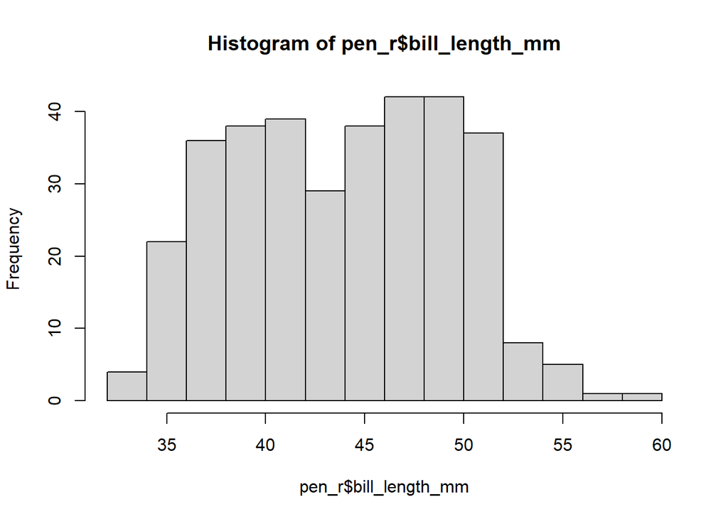

```r
hist(pen_r$bill_length_mm)
```

```r
pen_r <-
  pen_r |>
  mutate(blmc = case_when(bill_length_mm < 40 ~ "first",
                          bill_length_mm >= 40 & bill_length_mm < 50 ~ "second",
                          bill_length_mm >= 50 ~ "third"))

# 確認
pen_r |>
  count(blmc, bill_length_mm)
```

```
## # A tibble: 165 × 3
##   blmc  bill_length_mm     n
##   <chr>          <dbl> <int>
## 1 first           32.1     1
## 2 first           33.1     1
## 3 first           33.5     1
## 4 first           34       1
## 5 first           34.1     1
## # ℹ 160 more rows
```

```r
pen_r |>
  count(blmc)
```

```
## # A tibble: 4 × 2
##   blmc       n
##   <chr>  <int>
## 1 first    100
## 2 second   185
## 3 third     57
## 4 <NA>       2
```

#### 5.8.3.2 Python

##### 5.8.3.2.1 (現在はエラー？)方法1 np.select

##### 5.8.3.2.2 方法2 pd.cut

###### 5.8.3.2.2.1 デフォルトでは区分点までが範囲となる

```python
(
pen_p.assign(blmc2 = lambda x: pd.cut(x['bill_length_mm'],
                                              bins=[0, 40, 50, 100]))
     .value_counts(['blmc2'])

)
```

```
## blmc2
## (40, 50]     190
## (0, 40]      100
## (50, 100]     52
## Name: count, dtype: int64
```

###### 5.8.3.2.2.2 区分点未満までにするための引数

```python
(
pen_p.assign(blmc2 = lambda x: pd.cut(x['bill_length_mm'],
                                              bins=[0, 40, 50, 100],
                                              right = False))
     .value_counts(['blmc2'])

)
```

```
## blmc2
## [40, 50)     185
## [0, 40)      100
## [50, 100)     57
## Name: count, dtype: int64
```

###### 5.8.3.2.2.3 ラベル名付与

```python
(
pen_p.assign(blmc2 = lambda x: pd.cut(x['bill_length_mm'],
                                              bins=[0, 40, 50, 100],
                                              right = False,
                                              labels=["first", "second", "third"]))
     .value_counts(['blmc2'])
)
```

```
## blmc2
## second    185
## first     100
## third      57
## Name: count, dtype: int64
```

##### 5.8.3.2.3 方法3 np.where

- ただし，thirdのカテゴリにNAが含まれてしまうため，工夫が必要

```python
(
pen_p.assign(blmc3 = np.where(pen_p.bill_length_mm < 40, 'first',
                   (np.where(pen_p.bill_length_mm < 50, 'second', 'third'))
                   )
                   )
     .value_counts(['blmc3'])
)
```

```
## blmc3
## second    185
## first     100
## third      59
## Name: count, dtype: int64
```

- bill_length_mmがnanだった場合にblmc3をnanに変換

```python
pen_p = (
pen_p.assign(blmc3 = np.where(pen_p.bill_length_mm < 40, 'first',
                   (np.where(pen_p.bill_length_mm < 50, 'second', 'third'))
                   )
                   )
)

pen_p.loc[pen_p.bill_length_mm.isnull(), 'blmc3'] = np.nan

pen_p.value_counts(['blmc3'])
```

```
## blmc3
## second    185
## first     100
## third      57
## Name: count, dtype: int64
```

### 5.8.4 条件で新しい列作成

#### 5.8.4.1 R

```r
pen_r |>
  mutate(species2 = if_else(species == "Adelie", 1,0)) |>
  count(species, species2)
```

```
## # A tibble: 3 × 3
##   species   species2     n
##   <fct>        <dbl> <int>
## 1 Adelie           1   152
## 2 Chinstrap        0    68
## 3 Gentoo           0   124
```

#### 5.8.4.2 Python

```python
(
pen_p.assign(species2 = np.where(pen_p['species'].isin(['Adelie']), 1, 0))
     .value_counts(['species', 'species2'])
)
```

```
## species    species2
## Adelie     1           152
## Gentoo     0           124
## Chinstrap  0            68
## Name: count, dtype: int64
```

### 5.8.5

#### 5.8.5.1 R

#### 5.8.5.2 Python

## 5.9 要約値作成

### 5.9.1 変数1つのみ

#### 5.9.1.1 R

```r
pen_r |>
  summarise(blm_mean = mean(bill_length_mm,
                            na.rm = TRUE),
            blm_sd   = sd(bill_length_mm,
                            na.rm = TRUE),
            blm_n    = sum(!is.na(bill_length_mm)))
```

```
## # A tibble: 1 × 3
##   blm_mean blm_sd blm_n
##      <dbl>  <dbl> <int>
## 1     43.9   5.46   342
```

#### 5.9.1.2 Python

- 欠損値は自動で削除して計算されている

##### 5.9.1.2.1 pandas

```python
pen_p.bill_length_mm.mean()
```

```
## np.float64(43.9219298245614)
```

```python
pen_p.bill_length_mm.std()
```

```
## np.float64(5.4595837139265315)
```

```python
pen_p.bill_length_mm.count()
```

```
## np.int64(342)
```

- [pandas.DataFrame.aggregate](https://pandas.pydata.org/docs/reference/api/pandas.DataFrame.aggregate.html#)
- 短縮して`agg`で実行できる

```python
pen_p.bill_length_mm.agg(['mean', 'std', 'count'])
```

```
## mean      43.921930
## std        5.459584
## count    342.000000
## Name: bill_length_mm, dtype: float64
```

```python
# 結果をデータフレームで返すには

pen_p.agg({'bill_length_mm' : ['mean', 'std', 'count']})
```

```
##        bill_length_mm
## mean        43.921930
## std          5.459584
## count      342.000000
```

##### 5.9.1.2.2 polars

```python
pen_pl.select(pl.col('bill_length_mm').mean())
```

shape: (1, 1)

| bill_length_mm f64 |
| --- |
| 43.92193 |

```python
pen_pl.select(pl.col('bill_length_mm').std())
```

shape: (1, 1)

| bill_length_mm f64 |
| --- |
| 5.459584 |

```python
pen_pl.select(pl.col('bill_length_mm').count())
```

shape: (1, 1)

| bill_length_mm u32 |
| --- |
| 342 |

### 5.9.2 変数複数

#### 5.9.2.1 R

```r
pen_r |>
  summarise(across(c(bill_length_mm, bill_depth_mm),
                   list(mean = \(x) mean(x, na.rm = TRUE),
                          sd =  \(x) sd(x, na.rm = TRUE),
                           n =  \(x) sum(!is.na(x)))))
```

```
## # A tibble: 1 × 6
##   bill_length_mm_mean bill_length_mm_sd bill_length_mm_n bill_depth_mm_mean
##                 <dbl>             <dbl>            <int>              <dbl>
## 1                43.9              5.46              342               17.2
## # ℹ 2 more variables: bill_depth_mm_sd <dbl>, bill_depth_mm_n <int>
```

```r
# 列名格納版
cols <- c("bill_length_mm", "bill_depth_mm")
pen_r |>
  summarise(across(all_of(cols),
                   list(mean = \(x) mean(x, na.rm = TRUE),
                          sd =  \(x) sd(x, na.rm = TRUE),
                           n =  \(x) sum(!is.na(x)))))
```

```
## # A tibble: 1 × 6
##   bill_length_mm_mean bill_length_mm_sd bill_length_mm_n bill_depth_mm_mean
##                 <dbl>             <dbl>            <int>              <dbl>
## 1                43.9              5.46              342               17.2
## # ℹ 2 more variables: bill_depth_mm_sd <dbl>, bill_depth_mm_n <int>
```

#### 5.9.2.2 Python

##### 5.9.2.2.1 pandas

```python
pen_p.agg({'bill_length_mm' : ['mean', 'std', 'count'],
            'bill_depth_mm' : ['mean', 'std', 'count']})
```

```
##        bill_length_mm  bill_depth_mm
## mean        43.921930      17.151170
## std          5.459584       1.974793
## count      342.000000     342.000000
```

- 先に列選択すれば関数繰り返さなくてもよい

```python
pen_p[['bill_length_mm', 'bill_depth_mm']].agg(['mean', 'std', 'count'])
```

```
##        bill_length_mm  bill_depth_mm
## mean        43.921930      17.151170
## std          5.459584       1.974793
## count      342.000000     342.000000
```

```python
# 列名格納版
cols = ['bill_length_mm', 'bill_depth_mm']
pen_p[cols].agg(['mean', 'std', 'count'])
```

```
##        bill_length_mm  bill_depth_mm
## mean        43.921930      17.151170
## std          5.459584       1.974793
## count      342.000000     342.000000
```

##### 5.9.2.2.2 （動かない）polars

### 5.9.3 グループごとに集計

#### 5.9.3.1 R

```r
pen_r |>
  group_by(species) |>
  summarise(mean_blm = mean(bill_length_mm,
                            na.rm = TRUE))
```

```
## # A tibble: 3 × 2
##   species   mean_blm
##   <fct>        <dbl>
## 1 Adelie        38.8
## 2 Chinstrap     48.8
## 3 Gentoo        47.5
```

#### 5.9.3.2 Python

##### 5.9.3.2.1 pandas

- [python/pandas equivalent to dplyr 1.0.0 summarize(across())](https://stackoverflow.com/questions/63200530/python-pandas-equivalent-to-dplyr-1-0-0-summarizeacross)

```python
pen_p.groupby('species').agg({'bill_length_mm' : ['mean']})
```

```
##           bill_length_mm
##                     mean
## species
## Adelie         38.791391
## Chinstrap      48.833824
## Gentoo         47.504878
```

- series

```python
pen_p.groupby('species').bill_length_mm.agg('mean')
```

```
## species
## Adelie       38.791391
## Chinstrap    48.833824
## Gentoo       47.504878
## Name: bill_length_mm, dtype: float64
```

##### 5.9.3.2.2 （動かない）polars

*polars.dataframe.groupby.GroupBy.agg

### 5.9.4 データフレーム全体

#### 5.9.4.1 R

```r
pen_r |>
  summarise(across(where(is.numeric),
    mean, na.rm = TRUE))
```

```
## # A tibble: 1 × 5
##   bill_length_mm bill_depth_mm flipper_length_mm body_mass_g  year
##            <dbl>         <dbl>             <dbl>       <dbl> <dbl>
## 1           43.9          17.2              201.       4202. 2008.
```

#### 5.9.4.2 Python

##### 5.9.4.2.1 pandas

##### 5.9.4.2.2 polars

### 5.9.5 度数分布

#### 5.9.5.1 R

```r
pen_r |> count(species)
```

```
## # A tibble: 3 × 2
##   species       n
##   <fct>     <int>
## 1 Adelie      152
## 2 Chinstrap    68
## 3 Gentoo      124
```

```r
pen_r |> count(sex)
```

```
## # A tibble: 3 × 2
##   sex        n
##   <fct>  <int>
## 1 female   165
## 2 male     168
## 3 <NA>      11
```

#### 5.9.5.2 Python

##### 5.9.5.2.1 pandas

```python
pen_p.value_counts(['species'])
```

```
## species
## Adelie       152
## Gentoo       124
## Chinstrap     68
## Name: count, dtype: int64
```

```python
pen_p.value_counts(['sex'], dropna = False)
```

```
## sex
## Male      168
## Female    165
## NaN        11
## Name: count, dtype: int64
```

##### 5.9.5.2.2 polars

```python
pen_pl['species'].value_counts()
```

shape: (3, 2)

| species str | count u32 |
| --- | --- |
| "Adelie" | 152 |
| "Gentoo" | 124 |
| "Chinstrap" | 68 |

```python
pen_pl['sex'].value_counts()
```

shape: (3, 2)

| sex str | count u32 |
| --- | --- |
| "Male" | 168 |
| null | 11 |
| "Female" | 165 |

```python
pen_pl.select(
    [
        pl.col("sex").value_counts(sort=True),
    ]
    )
```

shape: (3, 1)

| sex struct[2] |
| --- |
| {"Male",168} |
| {"Female",165} |
| {null,11} |

### 5.9.6 複数列の組み合わせの度数

#### 5.9.6.1 R

```r
pen_r |> count(species, sex)
```

```
## # A tibble: 8 × 3
##   species   sex        n
##   <fct>     <fct>  <int>
## 1 Adelie    female    73
## 2 Adelie    male      73
## 3 Adelie    <NA>       6
## 4 Chinstrap female    34
## 5 Chinstrap male      34
## 6 Gentoo    female    58
## 7 Gentoo    male      61
## 8 Gentoo    <NA>       5
```

#### 5.9.6.2 Python

##### 5.9.6.2.1 pandas

```python
pen_p.value_counts(['species', 'sex'])
```

```
## species    sex
## Adelie     Female    73
##            Male      73
## Gentoo     Male      61
##            Female    58
## Chinstrap  Male      34
##            Female    34
## Name: count, dtype: int64
```

##### 5.9.6.2.2 polars（分からないので調べ中）

### 5.9.7 クロス表

#### 5.9.7.1 R

```r
table(pen_r$species, pen_r$sex)
```

```
##
##             female male
##   Adelie        73   73
##   Chinstrap     34   34
##   Gentoo        58   61
```

#### 5.9.7.2 Python

```python
pd.crosstab(pen_p['species'], pen_p['sex'])
```

```
## sex        Female  Male
## species
## Adelie         73    73
## Chinstrap      34    34
## Gentoo         58    61
```

```python
pd.crosstab(pen_p.species, pen_p.sex)
```

```
## sex        Female  Male
## species
## Adelie         73    73
## Chinstrap      34    34
## Gentoo         58    61
```

## 5.10 動詞をつなげる

### 5.10.1 R

- `|>`でつなげる

```r
pen_r |>
  select(species, bill_length_mm) |>
  filter(species == "Gentoo")
```

```
## # A tibble: 124 × 2
##   species bill_length_mm
##   <fct>            <dbl>
## 1 Gentoo            46.1
## 2 Gentoo            50
## 3 Gentoo            48.7
## 4 Gentoo            50
## 5 Gentoo            47.6
## # ℹ 119 more rows
```

### 5.10.2 Python

- [pandasチートシート]<https://pandas.pydata.org/Pandas_Cheat_Sheet.pdf
- `.`(ドット，ピリオド)でつなげてコード全体を`( )`で囲む

```python
(
  pen_p[['species', 'bill_length_mm']]
      .query('species == "Gentoo"')
 )
```

```
##     species  bill_length_mm
## 220  Gentoo            46.1
## 221  Gentoo            50.0
## 222  Gentoo            48.7
## 223  Gentoo            50.0
## 224  Gentoo            47.6
## ..      ...             ...
## 339  Gentoo             NaN
## 340  Gentoo            46.8
## 341  Gentoo            50.4
## 342  Gentoo            45.2
## 343  Gentoo            49.9
##
## [124 rows x 2 columns]
```

# 6 データフレームの連結や構造変換

## 6.1 データフレーム作成

### 6.1.1 R

```r
df_r_a <-
 tribble(
    ~id, ~x1, ~x2,
    1,  10,  50,
    2,  20,  60,
    3,  30,  70
  )

df_r_b <-
  tribble(
    ~id, ~x1, ~x3,
    1,  10,  80,
    2,  20,  90,
    4,  40, 100
  )

df_r_a
```

```
## # A tibble: 3 × 3
##      id    x1    x2
##   <dbl> <dbl> <dbl>
## 1     1    10    50
## 2     2    20    60
## 3     3    30    70
```

```r
df_r_b
```

```
## # A tibble: 3 × 3
##      id    x1    x3
##   <dbl> <dbl> <dbl>
## 1     1    10    80
## 2     2    20    90
## 3     4    40   100
```

### 6.1.2 Python

```python
df_py_a = pd.DataFrame([[1,10,50],
                        [2,20,60],
                        [3,30,70]],
              columns = ['id','x1','x2'])

df_py_b = pd.DataFrame([[1,10,80],
                        [2,20,90],
                        [4,40,100]],
              columns = ['id','x1','x3'])


df_py_a
```

```
##    id  x1  x2
## 0   1  10  50
## 1   2  20  60
## 2   3  30  70
```

```python
df_py_b
```

```
##    id  x1   x3
## 0   1  10   80
## 1   2  20   90
## 2   4  40  100
```

```python
# または

pd.DataFrame({'id':[1,2,3],
              'x1':[10,20,30],
              'x2':[50,60,70]})
```

```
##    id  x1  x2
## 0   1  10  50
## 1   2  20  60
## 2   3  30  70
```

## 6.2 キー変数を元に横に連結

- [dplyr::join](https://dplyr.tidyverse.org/reference/mutate-joins.html)
- [pandas.merge](https://pandas.pydata.org/docs/reference/api/pandas.merge.html#)

### 6.2.1 左に連結

#### 6.2.1.1 R

```r
df_r_a |>
  left_join(df_r_b, by = "id")
```

```
## # A tibble: 3 × 5
##      id  x1.x    x2  x1.y    x3
##   <dbl> <dbl> <dbl> <dbl> <dbl>
## 1     1    10    50    10    80
## 2     2    20    60    20    90
## 3     3    30    70    NA    NA
```

#### 6.2.1.2 Python

```python
pd.merge(df_py_a, df_py_b, on = 'id', how = 'left')
```

```
##    id  x1_x  x2  x1_y    x3
## 0   1    10  50  10.0  80.0
## 1   2    20  60  20.0  90.0
## 2   3    30  70   NaN   NaN
```

### 6.2.2 すべて連結

#### 6.2.2.1 R

```r
df_r_a |>
  full_join(df_r_b)
```

```
## # A tibble: 4 × 4
##      id    x1    x2    x3
##   <dbl> <dbl> <dbl> <dbl>
## 1     1    10    50    80
## 2     2    20    60    90
## 3     3    30    70    NA
## 4     4    40    NA   100
```

#### 6.2.2.2 Python

```python
pd.merge(df_py_a, df_py_b, how = 'outer')
```

```
##    id  x1    x2     x3
## 0   1  10  50.0   80.0
## 1   2  20  60.0   90.0
## 2   3  30  70.0    NaN
## 3   4  40   NaN  100.0
```

### 6.2.3 共通するデータの連結

#### 6.2.3.1 R

```r
df_r_a |>
  inner_join(df_r_b)
```

```
## # A tibble: 2 × 4
##      id    x1    x2    x3
##   <dbl> <dbl> <dbl> <dbl>
## 1     1    10    50    80
## 2     2    20    60    90
```

#### 6.2.3.2 Python

```python
pd.merge(df_py_a, df_py_b, how = 'inner')
```

```
##    id  x1  x2  x3
## 0   1  10  50  80
## 1   2  20  60  90
```

## 6.3 縦に連結

### 6.3.1 R

```r
# 連結用データ作成
df_r_b2 <-
  tribble(
    ~id, ~x1, ~x2, ~x3,
    4,  40, 80,  110,
    5,  50, 90,  120,
    6,  60, 100, 130
  )

df_r_b2
```

```
## # A tibble: 3 × 4
##      id    x1    x2    x3
##   <dbl> <dbl> <dbl> <dbl>
## 1     4    40    80   110
## 2     5    50    90   120
## 3     6    60   100   130
```

```r
# 縦に連結
df_r_a |>
  bind_rows(df_r_b2)
```

```
## # A tibble: 6 × 4
##      id    x1    x2    x3
##   <dbl> <dbl> <dbl> <dbl>
## 1     1    10    50    NA
## 2     2    20    60    NA
## 3     3    30    70    NA
## 4     4    40    80   110
## 5     5    50    90   120
## 6     6    60   100   130
```

#### 6.3.1.1 連結元データを示すidを付与

```r
df_r_a |>
  bind_rows(df_r_b2, .id = "df_id")
```

```
## # A tibble: 6 × 5
##   df_id    id    x1    x2    x3
##   <chr> <dbl> <dbl> <dbl> <dbl>
## 1 1         1    10    50    NA
## 2 1         2    20    60    NA
## 3 1         3    30    70    NA
## 4 2         4    40    80   110
## 5 2         5    50    90   120
## 6 2         6    60   100   130
```

- データフレーム名を付けたければ，一旦データフレームをリストに

```r
df_r_l <- list(df_r_a, df_r_b2) |>
  set_names("df_r_a", "df_r_b2")

bind_rows(df_r_l, .id = "df_id")
```

```
## # A tibble: 6 × 5
##   df_id      id    x1    x2    x3
##   <chr>   <dbl> <dbl> <dbl> <dbl>
## 1 df_r_a      1    10    50    NA
## 2 df_r_a      2    20    60    NA
## 3 df_r_a      3    30    70    NA
## 4 df_r_b2     4    40    80   110
## 5 df_r_b2     5    50    90   120
## 6 df_r_b2     6    60   100   130
```

### 6.3.2 Python

```python
# 連結用データ作成
df_py_b2 = pd.DataFrame([[4,40,80,110],
                         [5,50,90,120],
                         [6,60,100,130]],
              columns = ['id','x1','x2','x3'])

df_py_b2
```

```
##    id  x1   x2   x3
## 0   4  40   80  110
## 1   5  50   90  120
## 2   6  60  100  130
```

```python
# 縦に連結

pd.concat([df_py_a, df_py_b2])
```

```
##    id  x1   x2     x3
## 0   1  10   50    NaN
## 1   2  20   60    NaN
## 2   3  30   70    NaN
## 0   4  40   80  110.0
## 1   5  50   90  120.0
## 2   6  60  100  130.0
```

#### 6.3.2.1 連結元データを示すidを付与

```python
pd.concat([df_py_a, df_py_b2],
          keys = ['df_py_a', 'df_py_b2'])
```

```
##             id  x1   x2     x3
## df_py_a  0   1  10   50    NaN
##          1   2  20   60    NaN
##          2   3  30   70    NaN
## df_py_b2 0   4  40   80  110.0
##          1   5  50   90  120.0
##          2   6  60  100  130.0
```

## 6.4 縦横構造の変換

### 6.4.1 long形式に

#### 6.4.1.1 R

```r
df_r_a_long <-
df_r_a |>
pivot_longer(!id,
             names_to = "変数",
             values_to = "得点")

df_r_a_long
```

```
## # A tibble: 6 × 3
##      id 変数   得点
##   <dbl> <chr> <dbl>
## 1     1 x1       10
## 2     1 x2       50
## 3     2 x1       20
## 4     2 x2       60
## 5     3 x1       30
## 6     3 x2       70
```

#### 6.4.1.2 Python

```python
df_py_a_long = pd.melt(df_py_a,
                           id_vars = ['id'],
                           var_name = '変数',
                           value_name = '得点')

df_py_a_long
```

```
##    id  変数  得点
## 0   1  x1  10
## 1   2  x1  20
## 2   3  x1  30
## 3   1  x2  50
## 4   2  x2  60
## 5   3  x2  70
```

### 6.4.2 wide形式に

#### 6.4.2.1 R

```r
df_r_a_long |>
  pivot_wider(names_from = 変数,
              values_from = 得点)
```

```
## # A tibble: 3 × 3
##      id    x1    x2
##   <dbl> <dbl> <dbl>
## 1     1    10    50
## 2     2    20    60
## 3     3    30    70
```

#### 6.4.2.2 Python

- id列を示したい場合は，引数`index =`に列名を指定することで，indexとしてなら示せる

```python
df_py_a_long.pivot(index = ['id'],
                   columns = ['変数'],
                   values  = ['得点'])
```

```
##     得点
## 変数  x1  x2
## id
## 1   10  50
## 2   20  60
## 3   30  70
```

### 6.4.3 ※テンプレ

#### 6.4.3.1 R

#### 6.4.3.2 Python

# 7 ファイルの読み書き

## 7.1 ファイルの読み込み

### 7.1.1 Excelファイル

#### 7.1.1.1 R

```r
readxl::read_xlsx("data/ペンギン.xlsx")
```

```
## # A tibble: 344 × 9
##   species 種類     island    bill_length_mm bill_depth_mm flipper_length_mm
##   <chr>   <chr>    <chr>              <dbl>         <dbl>             <dbl>
## 1 Adelie  アデリー Torgersen           39.1          18.7               181
## 2 Adelie  アデリー Torgersen           39.5          17.4               186
## 3 Adelie  アデリー Torgersen           40.3          18                 195
## 4 Adelie  アデリー Torgersen           NA            NA                  NA
## 5 Adelie  アデリー Torgersen           36.7          19.3               193
## # ℹ 339 more rows
## # ℹ 3 more variables: body_mass_g <dbl>, sex <chr>, year <dbl>
```

#### 7.1.1.2 Python

```python
pd.read_excel('data/ペンギン.xlsx')
```

```
##        species    種類     island  ...  body_mass_g     sex  year
## 0       Adelie  アデリー  Torgersen  ...       3750.0    male  2007
## 1       Adelie  アデリー  Torgersen  ...       3800.0  female  2007
## 2       Adelie  アデリー  Torgersen  ...       3250.0  female  2007
## 3       Adelie  アデリー  Torgersen  ...          NaN     NaN  2007
## 4       Adelie  アデリー  Torgersen  ...       3450.0  female  2007
## ..         ...   ...        ...  ...          ...     ...   ...
## 339  Chinstrap    ヒゲ      Dream  ...       4000.0    male  2009
## 340  Chinstrap    ヒゲ      Dream  ...       3400.0  female  2009
## 341  Chinstrap    ヒゲ      Dream  ...       3775.0    male  2009
## 342  Chinstrap    ヒゲ      Dream  ...       4100.0    male  2009
## 343  Chinstrap    ヒゲ      Dream  ...       3775.0  female  2009
##
## [344 rows x 9 columns]
```

### 7.1.2 csvファイル

#### 7.1.2.1 utf-8

##### 7.1.2.1.1 R

```r
penr_csv <-
read_csv("data/ペンギン（ひどい列名）ver_utf8.csv")

penr_csv
```

```
## # A tibble: 344 × 9
##   Sｐｅｃｉｅｓ `種　類` `※島の名前` `①クチバシ　長さ（ｍｍ）`
##   <chr>         <chr>    <chr>                           <dbl>
## 1 Adelie        アデリー Torgersen                        39.1
## 2 Adelie        アデリー Torgersen                        39.5
## 3 Adelie        アデリー Torgersen                        40.3
## 4 Adelie        アデリー Torgersen                        NA
## 5 Adelie        アデリー Torgersen                        36.7
## # ℹ 339 more rows
## # ℹ 5 more variables: `②ｸﾁﾊﾞｼ＿大きさ（ｍｍ）` <dbl>, `翼：長さ(mm)` <dbl>,
## #   `■体重　単位はｇ` <dbl>, `㊛㊚` <chr>, `２００７～２００９` <dbl>
```

##### 7.1.2.1.2 Python

```python
penp_csv = pd.read_csv('data/ペンギン（ひどい列名）ver_utf8.csv')

penp_csv
```

```
##        Sｐｅｃｉｅｓ   種　類      ※島の名前  ...  ■体重　単位はｇ      ㊛㊚  ２００７～２００９
## 0       Adelie  アデリー  Torgersen  ...    3750.0    male       2007
## 1       Adelie  アデリー  Torgersen  ...    3800.0  female       2007
## 2       Adelie  アデリー  Torgersen  ...    3250.0  female       2007
## 3       Adelie  アデリー  Torgersen  ...       NaN     NaN       2007
## 4       Adelie  アデリー  Torgersen  ...    3450.0  female       2007
## ..         ...   ...        ...  ...       ...     ...        ...
## 339  Chinstrap    ヒゲ      Dream  ...    4000.0    male       2009
## 340  Chinstrap    ヒゲ      Dream  ...    3400.0  female       2009
## 341  Chinstrap    ヒゲ      Dream  ...    3775.0    male       2009
## 342  Chinstrap    ヒゲ      Dream  ...    4100.0    male       2009
## 343  Chinstrap    ヒゲ      Dream  ...    3775.0  female       2009
##
## [344 rows x 9 columns]
```

#### 7.1.2.2 shift-jis(cp932)

##### 7.1.2.2.1 R

```r
read_csv("data/ペンギン（ひどい列名）ver_cp932.csv",
         locale = locale(encoding = "cp932"))
```

```
## # A tibble: 344 × 9
##   Sｐｅｃｉｅｓ `種　類` `※島の名前` `①クチバシ　長さ（ｍｍ）`
##   <chr>         <chr>    <chr>                           <dbl>
## 1 Adelie        アデリー Torgersen                        39.1
## 2 Adelie        アデリー Torgersen                        39.5
## 3 Adelie        アデリー Torgersen                        40.3
## 4 Adelie        アデリー Torgersen                        NA
## 5 Adelie        アデリー Torgersen                        36.7
## # ℹ 339 more rows
## # ℹ 5 more variables: `②ｸﾁﾊﾞｼ＿大きさ（ｍｍ）` <dbl>, `翼：長さ(mm)` <dbl>,
## #   `■体重　単位はｇ` <dbl>, `??` <chr>, `２００７～２００９` <dbl>
```

##### 7.1.2.2.2 Python

```python
pd.read_csv('data/ペンギン（ひどい列名）ver_cp932.csv',
             encoding = 'cp932')
```

```
##        Sｐｅｃｉｅｓ   種　類      ※島の名前  ...  ■体重　単位はｇ      ??  ２００７～２００９
## 0       Adelie  アデリー  Torgersen  ...    3750.0    male       2007
## 1       Adelie  アデリー  Torgersen  ...    3800.0  female       2007
## 2       Adelie  アデリー  Torgersen  ...    3250.0  female       2007
## 3       Adelie  アデリー  Torgersen  ...       NaN     NaN       2007
## 4       Adelie  アデリー  Torgersen  ...    3450.0  female       2007
## ..         ...   ...        ...  ...       ...     ...        ...
## 339  Chinstrap    ヒゲ      Dream  ...    4000.0    male       2009
## 340  Chinstrap    ヒゲ      Dream  ...    3400.0  female       2009
## 341  Chinstrap    ヒゲ      Dream  ...    3775.0    male       2009
## 342  Chinstrap    ヒゲ      Dream  ...    4100.0    male       2009
## 343  Chinstrap    ヒゲ      Dream  ...    3775.0  female       2009
##
## [344 rows x 9 columns]
```

## 7.2 ファイルの書き出し

### 7.2.1 Excelファイル

#### 7.2.1.1 R

- `library(writexl)`を読み込んでいれば，`writexl::`は不要

```r
pen_r |>
  head(3) |>
  writexl::write_xlsx("out/pen_r_head.xlsx")
```

#### 7.2.1.2 Python

```python
pen_p.head(3).to_excel("out/pen_p_head.xlsx", index = False)
```

### 7.2.2 csvファイル

#### 7.2.2.1 R

```r
pen_r |>
  head(3) |>
  write_csv("out/pen_r_head.csv")
```

#### 7.2.2.2 Python

```python
pen_p.head(3).to_csv("out/pen_p_head.csv", index = False)
```

# 8 関数定義

- https://rstudio.github.io/reticulate/articles/python_primer.html#defining-functions-with-def

## 8.1 基本

### 8.1.1 R

```r
fn_r <- \(x){
  x + 1
}

fn_r(1)
```

```
## [1] 2
```

### 8.1.2 Python

```python
def fn_p(x):
  return x + 1

fn_p(1)
```

```
## 2
```

## 8.2 無名関数

### 8.2.1 R

```r
(function(x) x + 1)(1)
```

```
## [1] 2
```

```r
(\(x) x + 1)(1)
```

```
## [1] 2
```

### 8.2.2 Python

- https://www1.gifu-u.ac.jp/~fujilab/lambda_html/index.html

```python
(lambda x: x + 1)(1)
```

```
## 2
```

# 9 時間計測

## 9.1 R

```r
tictoc::tic()
pen_r |>
  arrange(bill_length_mm)
```

```
## # A tibble: 344 × 9
##   species island    bill_length_mm bill_depth_mm flipper_length_mm body_mass_g
##   <fct>   <fct>              <dbl>         <dbl>             <int>       <int>
## 1 Adelie  Dream               32.1          15.5               188        3050
## 2 Adelie  Dream               33.1          16.1               178        2900
## 3 Adelie  Torgersen           33.5          19                 190        3600
## 4 Adelie  Dream               34            17.1               185        3400
## 5 Adelie  Torgersen           34.1          18.1               193        3475
## # ℹ 339 more rows
## # ℹ 3 more variables: sex <fct>, year <int>, blmc <chr>
```

```r
tictoc::toc()
```

```
## 0.27 sec elapsed
```

## 9.2 Python

# 10 ※テンプレ

## 10.1

### 10.1.1 R

### 10.1.2 Python

# 11 参考情報

- [Python for Data Analysis, 3E](https://wesmckinney.com/book/)
- [Python Data Science Handbook](https://jakevdp.github.io/PythonDataScienceHandbook/)